# Kernel Ridge Regression

Timothy K. Book

## Description

This package may be used to create models via the kernel ridge regression smoothing method. While it is a neat smoothing method, it is not often used for two reasons:

1. Its computation involves inverting an $n \times n$ matrix, and thus suffers badly from computing inefficiency.
2. It tends to fare pretty poorly as a predictive model.

If you are still interesting in using this package, by all means, keep reading!

## Example Use of *krr*

Let us simulation some data:

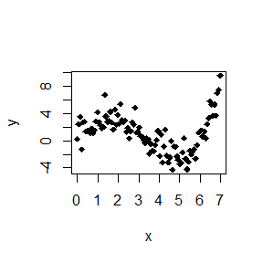

```r
set.seed(1234)
n <- 100
x <- seq(0, 7, length.out = n)
y <- 2 + x * sin(x) + rnorm(n, 0, sqrt(2))
plot(x, y, pch = 18)
```

While kernel ridge regression can handle an $n\times p$ design frame $\mathbf{X}$, my example is only $n\times 1$ in order to illustrate the model’s narrow usage through plotting.

### Producing a Model

Currently, objects of type `formula` are not accepted. The parameter `lambda` is mandatory, but `sigma` defaults to 1. `sigma` is the standard deviation parameter for the Gaussian kernel. Currently, the Gaussian kernel is the only kernel supported. (In my experience, it’s the best anyway).

[output not shown]

[output not shown]

```r
mod <- krr(x, y, lambda = 1, sigma = 1)
```

Several objects are returned from the `krr` function:

```r
names(mod)
```

```
## [1] "pred"      "alpha_hat" "lambda"    "ker"       "x"         "residuals"
## [7] "MSE"
```

- `pred` Are the predictions from the model, often denoted $\hat{f}$ or $\hat{y}$.
- `alpha_hat` Is the vector $\hat{\alpha}$ used in computing the model.
- `lambda` Is the input $\lambda$ parameter.
- `ker` Is the used kernel function.
- `x` Is the input design matrix $\mathbf{X}$.
- `residuals` Are the model residuals.
- `MSE` is the model mean squared errors $\sum (y - \hat{y})^2$

### Model Prediction

Notice that I provide a class type `krr`:

```r
class(mod)
```

```
## [1] "krr"
```

I also produce some S3 class methods. Specifically, a `predict.krr` method:

```r
n_new <- 20
x_new <- seq(2, 5, length.out = n_new)
pred_x <- predict(mod, xnew = x_new)
```

Which, given only `xnew`, produces only the model predictions:

```r
head(pred_x)
```

```
##          [,1]
## [1,] 3.077697
## [2,] 2.899002
## [3,] 2.667836
## [4,] 2.388769
## [5,] 2.062070
## [6,] 1.689195
```

However, if given a `ynew` parameter, an MSE is also produced:

```r
y_new <- 2 + x_new * sin(x_new) + rnorm(n_new, 0, sqrt(2))
pred_y <- predict(mod, xnew = x_new, ynew = y_new)
names(pred_y)
```

```
## [1] "pred" "MSE"
```

```r
head(pred_y$pred)
```

```
##          [,1]
## [1,] 3.077697
## [2,] 2.899002
## [3,] 2.667836
## [4,] 2.388769
## [5,] 2.062070
## [6,] 1.689195
```

```r
pred_y$MSE
```

```
## [1] 1.156105
```

### Plot

I also provide a `plot.krr` function, which only works when $p = 1$:

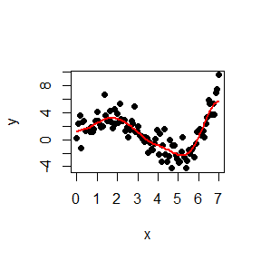

```r
plot(mod)
```

### Model Selection

Selecting an appropriate $\lambda$ is not easy. If we allow $\lambda$ to be too small, we have a near-perfect fit. If $\lambda$ is too large, our model hardly fits at all. I provide a function to aide in model fitting. However, due to matrix inversion, this function may take a long time for large $n$.

```r
cv <- cv_krr(x, y, lambda_index = seq(0.05, 0.15, 0.01))
names(cv)
```

```
## [1] "lambda_best" "MSE_best"    "index"       "model_best"
```

This function uses a crude mockery of cross-validation. The parameter `lambda_index` is a vector of $\lambda$s upon which to run the model.

```r
# Which lambda produced the lowest MSE?
cv$lambda_best
```

```
## [1] 0.13
```

```r
# Which MSE (corresponding to lambda_index) was lowest?
cv$MSE_best
```

[output not shown]

```r
# A data.frame of all lambda_index values and corresponding MSEs.
cv$index
```

```
##    lambda_index      MSE
## 1          0.05 2.779005
## 2          0.06 2.741878
## 3          0.07 2.715519
## 4          0.08 2.696765
## 5          0.09 2.683606
## 6          0.10 2.674692
## 7          0.11 2.669078
## 8          0.12 2.666084
## 9          0.13 2.665203
## 10         0.14 2.666052
## 11         0.15 2.668332
```

The object `cv$model_best` is an object of type `krr` produced using `cv$lambda_best`.

### Conclusion

And that’s it! I have a few `TODO`s in this package, but I don’t know if I’ll ever get to them, since I anticipate no high demand for these methods. If you have any requests or suggestions for refactoring/improving my code (would be much appreciated!), please email me at TimothyKBook@gmail.com.